# Social Network Analysis Home Assignment 3

due date - 05.06.2015 23:59

# Network communities

Please send your reports to hse.ntwks@gmail.com with the subject of of the following structure:  
*[MAGOLEGO SNA 2015] {LastName} {First Name} HA{Number}*

Late submission policy: -1 point per day

Use this file as a template for your report.  
Support your computations with figures and comments. Send ONLY .Rmd versions of your report.

## Yahoo Music Network

For this assignment, you have to load [the part of Yahoo Music Network](https://drive.google.com/file/d/0Bwd5a7NScgMtNElfOFdSbE1UYnM/view?usp=sharing). Archive contains network in GML format and corresponding list of artists.

```r
## Put your code here
g <- read.graph(file = "music2K.gml", format = "gml")
art <- scan('artists.txt', character(0), sep = "\n")

for (cnt in 1:length(V(g)))
    V(g)$label[cnt] <- art[cnt]
```

Edges in this network appear if enough number of users have given ratings to both music bands. Note, that edges are weighted with similarity of the ratings.

### 1. Preprocessing

This network needs to be preprocessed. Do the steps, described on seminar, to make it look properly. How many vertices and edges were deleted?

```r
## Put your code here
vertex1 <- length(V(g))
edges1 <- length(E(g))
g <- delete.vertices(g, degree(g) == 0)
g <- simplify(g)
vertex2 <- length(V(g))
edges2 <- length(E(g))

vertex1 - vertex2
```

```
## [1] 4
```

```r
edges1 - edges2
```

```
## [1] 0
```

### 2. Clustering

Define clusters for this networks using one of the algorithms described on lectures and seminars:

```r
## Put your code here
eb <- fastgreedy.community(g)
```

Compute density of obtained clusters:

```r
## Put your code here
elems <- list()
densities <- list()
for (i in 1:max(eb$membership)){
  g1 <- induced.subgraph(g, eb$membership == i)

  e1 <- sum(eb$membership == i)
  d1 <- graph.density(g1)
  elems[i] <- e1
  densities[i] <- d1

  print(sprintf("Cluster # %d with %d elements has density = %.4f", i, e1, d1))
  }
```

```
## [1] "Cluster # 1 with 97 elements has density = 0.0500"
## [1] "Cluster # 2 with 92 elements has density = 0.0602"
## [1] "Cluster # 3 with 150 elements has density = 0.0396"
## [1] "Cluster # 4 with 51 elements has density = 0.0808"
## [1] "Cluster # 5 with 53 elements has density = 0.1074"
## [1] "Cluster # 6 with 318 elements has density = 0.0190"
## [1] "Cluster # 7 with 168 elements has density = 0.0393"
## [1] "Cluster # 8 with 117 elements has density = 0.0475"
## [1] "Cluster # 9 with 77 elements has density = 0.0878"
## [1] "Cluster # 10 with 106 elements has density = 0.0613"
## [1] "Cluster # 11 with 123 elements has density = 0.0521"
## [1] "Cluster # 12 with 27 elements has density = 0.2308"
## [1] "Cluster # 13 with 71 elements has density = 0.0684"
## [1] "Cluster # 14 with 55 elements has density = 0.1010"
## [1] "Cluster # 15 with 24 elements has density = 0.1703"
## [1] "Cluster # 16 with 179 elements has density = 0.0375"
## [1] "Cluster # 17 with 21 elements has density = 0.2286"
## [1] "Cluster # 18 with 70 elements has density = 0.0981"
## [1] "Cluster # 19 with 18 elements has density = 0.3399"
## [1] "Cluster # 20 with 34 elements has density = 0.1355"
## [1] "Cluster # 21 with 47 elements has density = 0.1277"
## [1] "Cluster # 22 with 33 elements has density = 0.1345"
## [1] "Cluster # 23 with 13 elements has density = 0.5385"
## [1] "Cluster # 24 with 24 elements has density = 0.2536"
## [1] "Cluster # 25 with 7 elements has density = 0.5238"
## [1] "Cluster # 26 with 13 elements has density = 0.5769"
## [1] "Cluster # 27 with 8 elements has density = 0.6429"
```

Compute the ratio of inner clusters connections to outer ones:

```r
## Put your code here
for (i in 1:max(eb$membership)){
  h = induced.subgraph(g, eb$membership == i)
  edges_all = length(E(g))
  edges_in = length(E(h))
  edges_out = length(E(induced.subgraph(g,!(eb$membership == i))))
  edges_between = edges_all - edges_in - edges_out
  print(sprintf("Ratio for cluster # %d = %.3f",i, edges_in/edges_between))
}
```

```
## [1] "Ratio for cluster # 1 = 5.295"
## [1] "Ratio for cluster # 2 = 3.818"
## [1] "Ratio for cluster # 3 = 4.210"
## [1] "Ratio for cluster # 4 = 1.051"
## [1] "Ratio for cluster # 5 = 10.571"
## [1] "Ratio for cluster # 6 = 3.609"
## [1] "Ratio for cluster # 7 = 3.203"
## [1] "Ratio for cluster # 8 = 2.901"
## [1] "Ratio for cluster # 9 = 5.039"
## [1] "Ratio for cluster # 10 = 9.743"
## [1] "Ratio for cluster # 11 = 3.342"
## [1] "Ratio for cluster # 12 = 3.375"
## [1] "Ratio for cluster # 13 = 3.542"
## [1] "Ratio for cluster # 14 = 3.659"
## [1] "Ratio for cluster # 15 = 6.714"
## [1] "Ratio for cluster # 16 = 2.345"
## [1] "Ratio for cluster # 17 = 2.087"
## [1] "Ratio for cluster # 18 = 19.750"
## [1] "Ratio for cluster # 19 = 4.000"
## [1] "Ratio for cluster # 20 = 4.471"
## [1] "Ratio for cluster # 21 = 2.226"
## [1] "Ratio for cluster # 22 = 4.438"
## [1] "Ratio for cluster # 23 = 3.818"
## [1] "Ratio for cluster # 24 = 70.000"
## [1] "Ratio for cluster # 25 = 5.500"
## [1] "Ratio for cluster # 26 = 3.462"
## [1] "Ratio for cluster # 27 = 4.500"
```

### 3. Visualization & interpretation

Visulize three of the biggest clusters.

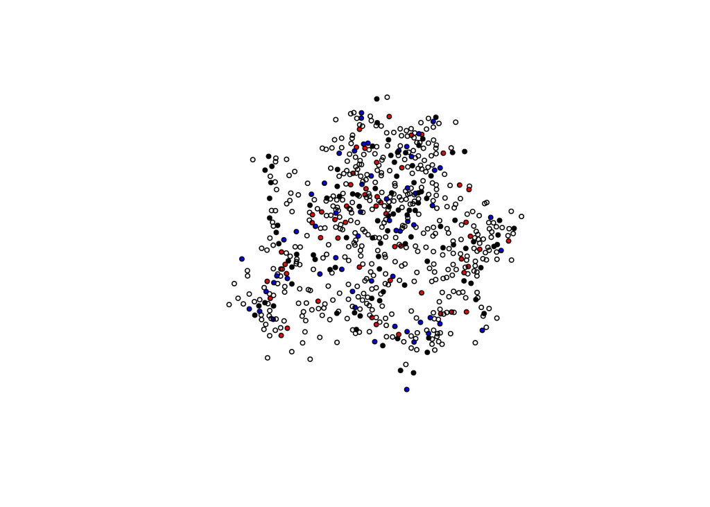

```r
## Put your code here
index_max1 <- which.max(elems)
elems[index_max1] <- 0
index_max2 <- which.max(elems)
elems[index_max2] <- 0
index_max3 <- which.max(elems)

subgraph <- induced.subgraph(g,(c((which(eb$membership == index_max1)),(which(eb$membership == index_max2)),((which(eb$membership == index_max3))))))
V(subgraph)[which(eb$membership == index_max1)]$color = 'black'
V(subgraph)[which(eb$membership == index_max2)]$color = 'blue'
V(subgraph)[which(eb$membership == index_max3)]$color = 'red'

plot(subgraph, layout=layout.fruchterman.reingold, vertex.size=3, edge.width = 0.005, vertex.label=NA)
```

Visulize three of the most dense clusters. Use artists’ names as labels.

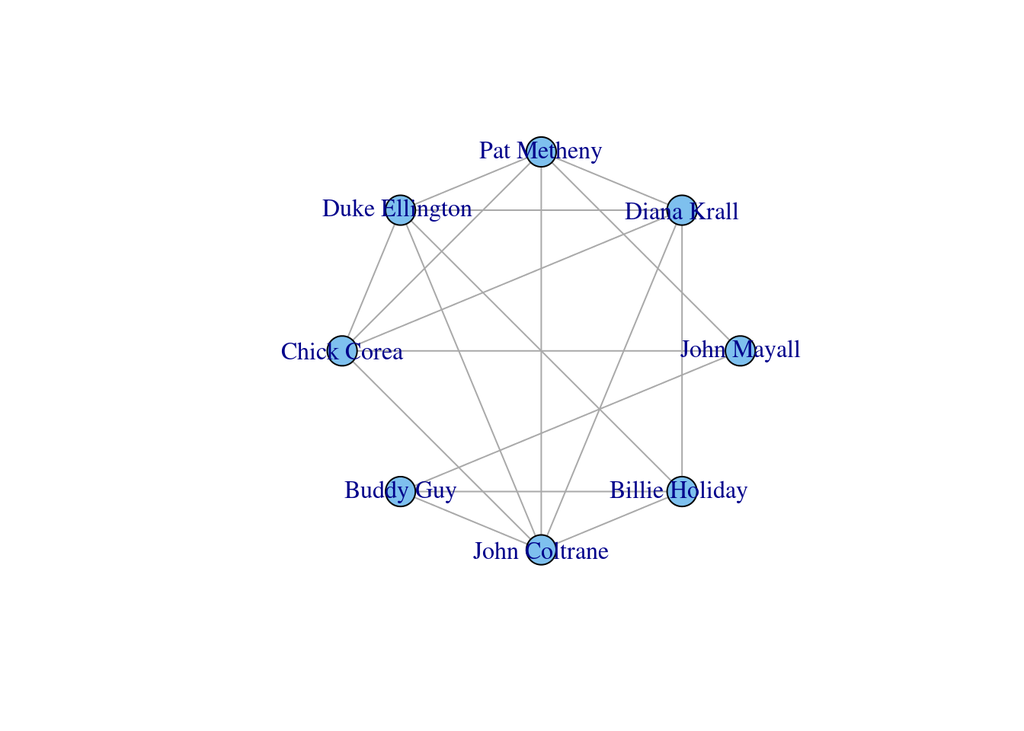

```r
index_max1 <- which.max(densities)
densities[index_max1] <- 0
index_max2 <- which.max(densities)
densities[index_max2] <- 0
index_max3 <- which.max(densities)

subgraph <- induced.subgraph(g,which(eb$membership == index_max1))
plot(subgraph, layout=layout.circle)
```

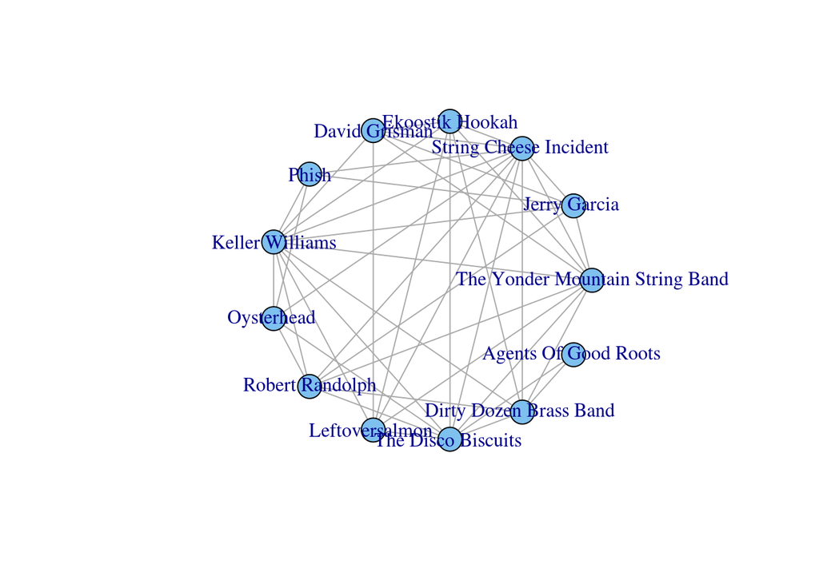

```r
subgraph <- induced.subgraph(g,which(eb$membership == index_max2))
plot(subgraph, layout=layout.circle)
```

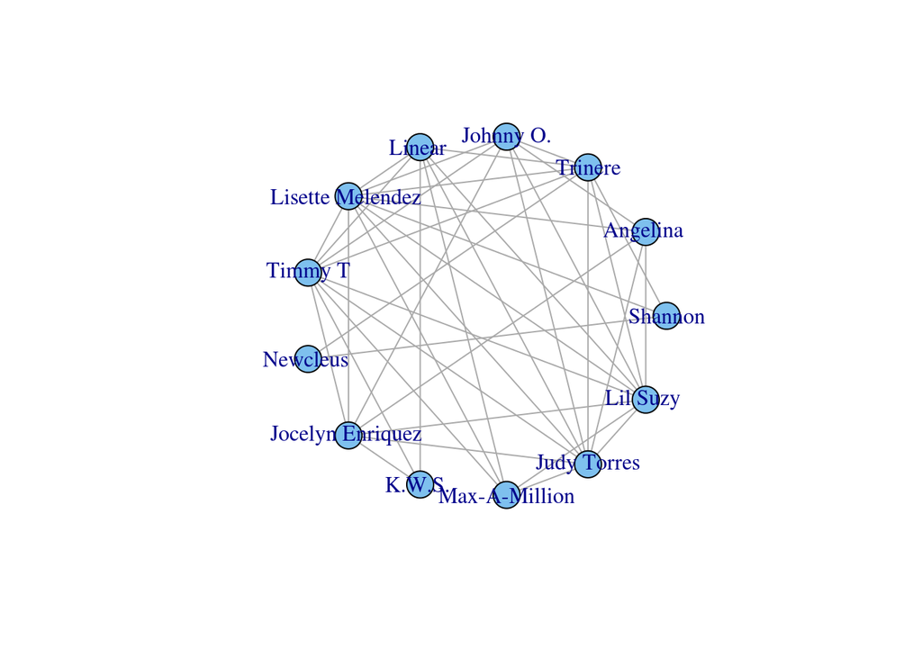

```r
subgraph <- induced.subgraph(g,which(eb$membership == index_max3))
plot(subgraph, layout=layout.circle)
```

**(Extra task)** Try to interpret (using Wikipedia or other resources) obtained clusters.